# SQL

In order to prove my skills in the field of data handling and SQL, this page will show me work with flu data, dengue data and the gapminder data from the {dslabs} package. The flu data and dengue data are both supplied by google, “www.google.org/flutrends AND www.google.org/denguetrends”

First of all, all datasets will be read and inspected in R

```r
#The gapminder dataset
gapminder %>% head()
```

```
##               country year infant_mortality life_expectancy fertility population          gdp continent          region
## 1             Albania 1960           115.40           62.87      6.19    1636054           NA    Europe Southern Europe
## 2             Algeria 1960           148.20           47.50      7.65   11124892  13828152297    Africa Northern Africa
## 3              Angola 1960           208.00           35.98      7.32    5270844           NA    Africa   Middle Africa
## 4 Antigua and Barbuda 1960               NA           62.97      4.43      54681           NA  Americas       Caribbean
## 5           Argentina 1960            59.87           65.39      3.11   20619075 108322326649  Americas   South America
## 6             Armenia 1960               NA           66.86      4.55    1867396           NA      Asia    Western Asia
```

```r
dengue<-read.csv("./data.raw/dengue_data.csv", skip = 10)
#The dengue dataset
dengue %>% head()
```

```
##         Date Argentina Bolivia Brazil India Indonesia Mexico Philippines Singapore Thailand Venezuela
## 1 2002-12-29        NA   0.101  0.073 0.062     0.101     NA          NA     0.059       NA        NA
## 2 2003-01-05        NA   0.143  0.098 0.047     0.039     NA          NA     0.059       NA        NA
## 3 2003-01-12        NA   0.176  0.119 0.051     0.059  0.071          NA     0.238       NA        NA
## 4 2003-01-19        NA   0.173  0.170 0.032     0.039  0.052          NA     0.175       NA        NA
## 5 2003-01-26        NA   0.146  0.138 0.040     0.112  0.048          NA     0.164       NA        NA
## 6 2003-02-02        NA   0.160  0.202 0.038     0.049  0.041          NA     0.163       NA        NA
```

```r
flu<-read.csv("./data.raw/flu_data.csv", skip = 10)
#The flu dataset
flu %>% dplyr::select(Date:Japan) %>% head() #Selected till Japan for a cleaner table
```

```
##         Date Argentina Australia Austria Belgium Bolivia Brazil Bulgaria Canada Chile France Germany Hungary Japan
## 1 2002-12-29        NA        NA      NA      NA      NA    174       NA     NA    NA     NA      NA      NA    NA
## 2 2003-01-05        NA        NA      NA      NA      NA    162       NA     NA    NA     NA      NA      NA    NA
## 3 2003-01-12        NA        NA      NA      NA      NA    174       NA     NA     1     NA      NA      NA    NA
## 4 2003-01-19        NA        NA      NA      NA      NA    162       NA     NA     0     NA      NA      NA    NA
## 5 2003-01-26        NA        NA      NA      NA      NA    131       NA     NA     0     NA      NA      NA    NA
## 6 2003-02-02       136        NA      NA      NA      NA    151       NA     NA     0     NA      NA      NA    NA
```

Both the flu and the dengue datasets are not tidy: Each row contains the incidence rate (observation) of dengue/flu of multiple countries, while each row is only supposed to have 1 observation. The datasets will be wrangled to be tidy

```r
dengue_tidy<-dengue %>% pivot_longer(cols = Argentina:Venezuela,
                        names_to = "country",
                        values_to = "dengue_incidence")
dengue_tidy %>% head()
```

```
## # A tibble: 6 x 3
##   Date       country   dengue_incidence
##   <chr>      <chr>                <dbl>
## 1 2002-12-29 Argentina           NA
## 2 2002-12-29 Bolivia              0.101
## 3 2002-12-29 Brazil               0.073
## 4 2002-12-29 India                0.062
## 5 2002-12-29 Indonesia            0.101
## 6 2002-12-29 Mexico              NA
```

```r
flu_tidy<-flu %>% pivot_longer(cols = Argentina:Uruguay,
                     names_to = "country",
                     values_to = "flu_incidence")
flu_tidy %>% head()
```

```
## # A tibble: 6 x 3
##   Date       country   flu_incidence
##   <chr>      <chr>             <int>
## 1 2002-12-29 Argentina            NA
## 2 2002-12-29 Australia            NA
## 3 2002-12-29 Austria              NA
## 4 2002-12-29 Belgium              NA
## 5 2002-12-29 Bolivia              NA
## 6 2002-12-29 Brazil              174
```

Now the data is tidy, however, to make the dengue/flu data relational, the “date” data needs to be properly synchronized. To do this, the “date” will be split into “year”, “month” and “day”. These will be changed from character vectors to integers

```r
flu_separate<-flu_tidy %>% separate(col = Date, into = c("year", "month", "day"))
flu_separate$year<-flu_separate$year %>% as.integer()
flu_separate$month<-flu_separate$month %>% as.integer()
flu_separate$day<-flu_separate$day %>% as.integer()

dengue_separate<-dengue_tidy %>% separate(col = Date, into = c("year", "month", "day"))
dengue_separate$year<-dengue_separate$year %>% as.integer()
dengue_separate$month<-dengue_separate$month %>% as.integer()
dengue_separate$day<-dengue_separate$day %>% as.integer()
```

Now, with the data properly relational, it’ll be written into .csv’s and .rds’

```r
flu_separate %>% write.csv(file = "./data/flu.csv")
flu_separate %>% write_rds(file = "./data/flu.rds")
dengue_separate %>% write.csv(file = "./data/dengue.csv")
dengue_separate %>% write_rds(file = "./data/dengue.rds")
gapminder %>% write.csv(file = "./data/gapminder.csv")
gapminder %>% write_rds(file = "./data/gapminder.rds")
```

Using the SQL script shown in the screenshot below, a SQL database has been created called “workflowsdb”.

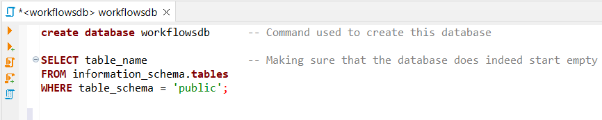

Using RPostgreSQL, the created datasets will be inserted into this database

(Creating a connection with SQL requires a password: in order to prevent the leakage of my password, local datafiles have been used instead of using the datafiles from an SQL database. The code which would be used *if* I were to use my password will still be shown)

```r
source(here("R/login_credentials.R"))
con <- dbConnect(RPostgres::Postgres(),
                 dbname = "workflowsdb",
                 host = "localhost",
                 port = 5432,
                 user= "postgres",
                 password = rawToChar(pwd))

dbWriteTable(con, "gapminder", gapminder)
dbWriteTable(con, "dengue", dengue_separate)
dbWriteTable(con, "flu", flu_separate)
```

To inspect the database in order to check if all data has been transfered correctly, another SQL script has been used. Once again, screenshots of this script have been added underneath.

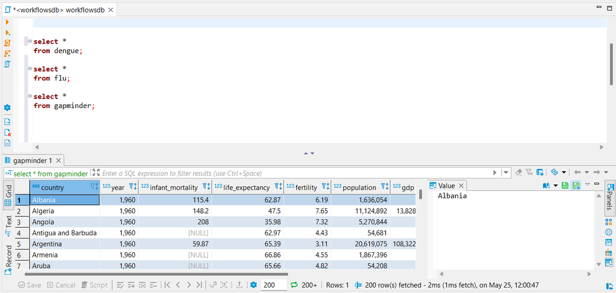

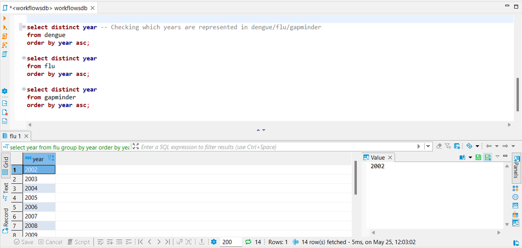

For further insurance, the data will also be inspected via R

```r
source(here("R/login_credentials.R"))
con <- dbConnect(RPostgres::Postgres(),
                 dbname = "workflowsdb",
                 host = "localhost",
                 port = 5432,
                 user= "postgres",
                 password = rawToChar(pwd))

gapminder<-dbReadTable(con, "gapminder")
dengue<-dbReadTable(con, "dengue")
flu<-dbReadTable(con, "flu")
```

We want to join the datasets based on “year” and on “countries”, thus we shall inspect those character vectors in partciular

```r
list(gapminder_years=gapminder$year %>% unique(),
     dengue_years=dengue$year %>% unique(),
     flu_years=flu$year %>% unique())
```

```
## $gapminder_years
##  [1] 1960 1961 1962 1963 1964 1965 1966 1967 1968 1969 1970 1971 1972 1973 1974 1975 1976 1977 1978 1979 1980 1981 1982 1983 1984 1985 1986 1987 1988 1989 1990
## [32] 1991 1992 1993 1994 1995 1996 1997 1998 1999 2000 2001 2002 2003 2004 2005 2006 2007 2008 2009 2010 2011 2012 2013 2014 2015 2016
##
## $dengue_years
##  [1] 2002 2003 2004 2005 2006 2007 2008 2009 2010 2011 2012 2013 2014 2015
##
## $flu_years
##  [1] 2002 2003 2004 2005 2006 2007 2008 2009 2010 2011 2012 2013 2014 2015
```

Based on the years, we can state that dengue and flu share the same range of years, while gapminder has a way bigger range of years it covers

```r
list(gapminder_countries=gapminder$country %>% unique %>% head(50),
     dengue_countries=dengue$country %>% unique,
     flu_countries=flu$country %>% unique)
```

```
## $gapminder_countries
##  [1] "Albania"                  "Algeria"                  "Angola"                   "Antigua and Barbuda"      "Argentina"
##  [6] "Armenia"                  "Aruba"                    "Australia"                "Austria"                  "Azerbaijan"
## [11] "Bahamas"                  "Bahrain"                  "Bangladesh"               "Barbados"                 "Belarus"
## [16] "Belgium"                  "Belize"                   "Benin"                    "Bhutan"                   "Bolivia"
## [21] "Bosnia and Herzegovina"   "Botswana"                 "Brazil"                   "Brunei"                   "Bulgaria"
## [26] "Burkina Faso"             "Burundi"                  "Cambodia"                 "Cameroon"                 "Canada"
## [31] "Cape Verde"               "Central African Republic" "Chad"                     "Chile"                    "China"
## [36] "Colombia"                 "Comoros"                  "Congo, Dem. Rep."         "Congo, Rep."              "Costa Rica"
## [41] "Cote d'Ivoire"            "Croatia"                  "Cuba"                     "Cyprus"                   "Czech Republic"
## [46] "Denmark"                  "Djibouti"                 "Dominican Republic"       "Ecuador"                  "Egypt"
##
## $dengue_countries
##  [1] "Argentina"   "Bolivia"     "Brazil"      "India"       "Indonesia"   "Mexico"      "Philippines" "Singapore"   "Thailand"    "Venezuela"
##
## $flu_countries
##  [1] "Argentina"     "Australia"     "Austria"       "Belgium"       "Bolivia"       "Brazil"        "Bulgaria"      "Canada"        "Chile"
## [10] "France"        "Germany"       "Hungary"       "Japan"         "Mexico"        "Netherlands"   "New.Zealand"   "Norway"        "Paraguay"
## [19] "Peru"          "Poland"        "Romania"       "Russia"        "South.Africa"  "Spain"         "Sweden"        "Switzerland"   "Ukraine"
## [28] "United.States" "Uruguay"
```

```r
dengue_countries<-dengue$country %>% unique()
dengue_flu_countries<-flu$country %>% str_extract(pattern = dengue_countries) %>% unique() #Filtering for countries which are present in both dengue and flu
dengue_flu_countries<-dengue_flu_countries[!is.na(dengue_flu_countries)] #Filtering for NA's

gapminder$country %>% str_subset(pattern = dengue_flu_countries) %>% unique
```

```
## [1] "Argentina" "Brazil"    "Mexico"    "Bolivia"
```

Based on these filters, the for countries available in every dataset are: Argentina, Brazil, Mexico, Bolivia

```r
flu_year<-flu$year

gapminder_join<-gapminder %>% filter(year <= max(flu_year) & year >=min(flu_year)) %>%
  filter(country %in% dengue_flu_countries)

data_full<-left_join(gapminder_join, dengue, by = c("country", "year")) %>% left_join(flu, by = c("country", "year", "month", "day"))
```

Now, with this fully joined dataset filtered for both mutual countries and years, some visualisations will be performed

```r
data_sum_dengue<-data_full %>% group_by(country, year) %>%
  summarise(mean=mean(dengue_incidence, na.rm=TRUE))
```

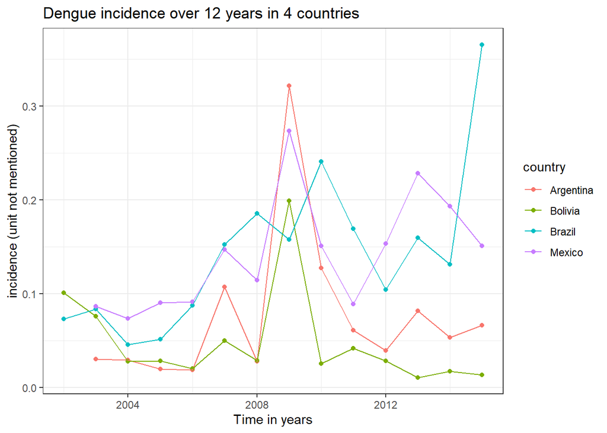

```r
data_sum_dengue %>% ggplot(aes(x=year, y=mean))+
  geom_point(aes(color = country))+
  geom_line(aes(color = country))+
  labs(
    title="Dengue incidence over 12 years in 4 countries",
    x="Time in years",
    y="incidence (unit not mentioned)"
  )+
  theme_bw()
```

Secondly, the incidence of flue through the months in the 4 different countries

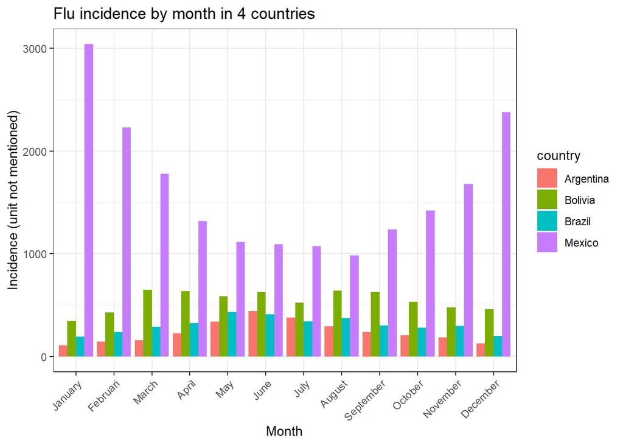

```r
month_data<-data.frame(
  month=seq(1:12),
  MONTH=c("January", "Februari", "March", "April", "May", "June", "July", "August", "September", "October", "November", "December")
)

month_data$MONTH<-factor(month_data$MONTH, levels =c("January", "Februari", "March", "April", "May", "June", "July", "August", "September", "October", "November", "December"))

data_month<-left_join(data_full, month_data, by="month")

data_month %>% ggplot(aes(x=MONTH, y=flu_incidence))+
  geom_col(aes(fill=country), position = position_dodge())+
  labs(
    title="Flu incidence by month in 4 countries",
    x="Month",
    y="Incidence (unit not mentioned)"
  )+
  theme_bw()+
  theme(axis.text.x = element_text(angle=45, hjust=1))
```

And finally, a correlation between dengue incidence and flu incidence? (Spoiler: no. Not at all.)

[figure not shown]

```r
correlation<-cor.test(data_full$dengue_incidence, data_full$flu_incidence, method=c("pearson"))$estimate %>% round(digits = 3)

data_full %>% ggplot(aes(x=flu_incidence, y=dengue_incidence))+
  geom_point(aes(color=country), alpha = 0.8)+
  labs(
    title="Correlation between flu incidence and dengue incidence",
    y="Flu incidence (unit not mentioned)",
    y="Dengue incidence (unit not mentioned"
  )+
  annotate("text", x=2600, y=0.95, label = paste0("Pearson's correlation: \n", correlation))+
  theme_bw()
```